# graduate-admission

```python
# This Python 3 environment comes with many helpful analytics libraries installed
# It is defined by the kaggle/python docker image: https://github.com/kaggle/docker-python
# For example, here's several helpful packages to load in

import numpy as np # linear algebra
import pandas as pd # data processing, CSV file I/O (e.g. pd.read_csv)
import re
# Input data files are available in the "../input/" directory.
# For example, running this (by clicking run or pressing Shift+Enter) will list all files under the input directory

import os
for dirname, _, filenames in os.walk('/kaggle/input'):
    for filename in filenames:
        print(os.path.join(dirname, filename))

# Any results you write to the current directory are saved as output.
```

```
/kaggle/input/graduate-admissions/Admission_Predict.csv
/kaggle/input/graduate-admissions/Admission_Predict_Ver1.1.csv
```

This is a notebook to play with models, data visualization and feature engineering! More than focusing on model performance or machine learning theory, is has as main purpose to visualize how each parameter can change the output of a function (it can be just seing a graph).

```python
import seaborn as sns
import matplotlib.pyplot as plt
import itertools
from scipy.stats import pearsonr
from sklearn.utils import shuffle
```

```python
data = pd.read_csv("../input/graduate-admissions/Admission_Predict_Ver1.1.csv", index_col = "Serial No." )

data.head()
```

| Serial No. | GRE Score | TOEFL Score | University Rating | SOP | LOR | CGPA | Research | Chance of Admit |
| --- | --- | --- | --- | --- | --- | --- | --- | --- |
| 1 | 337 | 118 | 4 | 4.5 | 4.5 | 9.65 | 1 | 0.92 |
| 2 | 324 | 107 | 4 | 4.0 | 4.5 | 8.87 | 1 | 0.76 |
| 3 | 316 | 104 | 3 | 3.0 | 3.5 | 8.00 | 1 | 0.72 |
| 4 | 322 | 110 | 3 | 3.5 | 2.5 | 8.67 | 1 | 0.80 |
| 5 | 314 | 103 | 2 | 2.0 | 3.0 | 8.21 | 0 | 0.65 |

```python
data.describe()
```

|  | GRE Score | TOEFL Score | University Rating | SOP | LOR | CGPA | Research | Chance of Admit |
| --- | --- | --- | --- | --- | --- | --- | --- | --- |
| count | 500.000000 | 500.000000 | 500.000000 | 500.000000 | 500.00000 | 500.000000 | 500.000000 | 500.00000 |
| mean | 316.472000 | 107.192000 | 3.114000 | 3.374000 | 3.48400 | 8.576440 | 0.560000 | 0.72174 |
| std | 11.295148 | 6.081868 | 1.143512 | 0.991004 | 0.92545 | 0.604813 | 0.496884 | 0.14114 |
| min | 290.000000 | 92.000000 | 1.000000 | 1.000000 | 1.00000 | 6.800000 | 0.000000 | 0.34000 |
| 25% | 308.000000 | 103.000000 | 2.000000 | 2.500000 | 3.00000 | 8.127500 | 0.000000 | 0.63000 |
| 50% | 317.000000 | 107.000000 | 3.000000 | 3.500000 | 3.50000 | 8.560000 | 1.000000 | 0.72000 |
| 75% | 325.000000 | 112.000000 | 4.000000 | 4.000000 | 4.00000 | 9.040000 | 1.000000 | 0.82000 |
| max | 340.000000 | 120.000000 | 5.000000 | 5.000000 | 5.00000 | 9.920000 | 1.000000 | 0.97000 |

If we would like to slice the data visualization for a feature (uncomment the cell below):

```python
# fig, ax = plt.subplots(1,7,figsize=(16,6))
# for i in range(4,10):
#     val = data.loc[(data["Chance of Admit "] > 0.1*i) & (data["Chance of Admit "] < 0.1*(1+i))]
# #print(val)
#     sns.scatterplot(y= val["CGPA"], x=val["Chance of Admit "],ax=ax[i-3])
# #sns.scatterplot(x= data["CGPA"], y=data.loc["Chance of Admit "],ax=ax[1])
# fig, ax = plt.subplots(1,7,figsize=(16,8))
# for i in range(4,10):
#     val = data.loc[(data["Chance of Admit "] > 0.1*i) & (data["Chance of Admit "] < 0.1*(1+i))]
# #print(val)
#     sns.scatterplot(y= val["TOEFL Score"], x=val["Chance of Admit "],ax=ax[i-3])
```

Lets look to how much variation exists in Chance of Admit for each TOEFL Score values:

```python
### ONLY FOR TOEFL = 92
toefMax = data.loc[(data["TOEFL Score"]==92)]["Chance of Admit "].max()
toefMin = data.loc[(data["TOEFL Score"]==92)]["Chance of Admit "].min()
print("max and min for 92: {}, {}".format(toefMax,toefMin))
```

```
max and min for 92: 0.51, 0.51
```

Finding all possible TOEFL Scores and calculating the Chance of Admit variation for them (t_val):

```python
t_u = sorted(data["TOEFL Score"].unique())

t_val = pd.Series(index=t_u)
for un in data["TOEFL Score"].unique():
    t_max = data.loc[(data["TOEFL Score"]==un)]["Chance of Admit "].max()
    t_min = data.loc[(data["TOEFL Score"]==un)]["Chance of Admit "].min()
    t_val[un] = t_max - t_min
t_val
```

```
92     0.00
93     0.00
94     0.14
95     0.18
96     0.20
97     0.27
98     0.42
99     0.40
100    0.36
101    0.41
102    0.30
103    0.24
104    0.40
105    0.40
106    0.29
107    0.31
108    0.42
109    0.23
110    0.46
111    0.41
112    0.41
113    0.20
114    0.35
115    0.25
116    0.18
117    0.09
118    0.04
119    0.08
120    0.11
dtype: float64
```

```python
# import numpy as np
# #print(len(t_val))
# y = np.arange(0,1,(1/len(t_val)))
# #print(y)
# plt.figure(figsize=(10,10))
# plt.errorbar(t_val.index, y, yerr=t_val,uplims=True, lolims=True)
```

Getting some correlations between all the parameters to see their "dependency":

```python
cor = []
for one,two in itertools.combinations(data.columns,2):
    #plt.figure(figsize=(15,15))
    cor.append(f"Correlation btw {one} and {two} is: {pearsonr(data[one],data[two])}")
    #sns.regplot(x=one,y=two,data=data)
```

```python
from heapq import nlargest
from operator import itemgetter
all_cor = []
all_cord = {}
for one,two in itertools.combinations(data.columns,2):
    #plt.figure(figsize=(15,15))
    v,_ = pearsonr(data[one],data[two])
    all_cor.append(f"Correlation btw {one} and {two} is: {v:.4f}")
    all_cord[one+"-"+two] = round(v,4)
    #sns.regplot(x=one,y=two,data=data)
all_cor
#va = [re.findall("\d+\.\d+", x) for x in all_cor]
#print("The 4 strongest correlations are : ",nlargest(4,[re.findall("\d+\.\d+", x) for x, in all_cor]))
m = dict(sorted(all_cord.items(), key = itemgetter(1), reverse = True)[:4])
print("The 4 strongest correlations are : ",m)
#print(all_cord)
```

```
The 4 strongest correlations are :  {'CGPA-Chance of Admit ': 0.8824, 'GRE Score-TOEFL Score': 0.8272, 'GRE Score-CGPA': 0.8259, 'TOEFL Score-CGPA': 0.8106}
```

We could eventually create new features from the combinations of these parameters.

```python
data.columns
```

```
Index(['GRE Score', 'TOEFL Score', 'University Rating', 'SOP', 'LOR ', 'CGPA',
       'Research', 'Chance of Admit '],
      dtype='object')
```

Below, the strongest correlation between each feature and the Chance of Admission:

```python
adm_cor = []
for col in data.columns.drop(["Chance of Admit "]):
    #plt.figure(figsize=(15,15))
    v,_ = pearsonr(data[col],data["Chance of Admit "])
    adm_cor.append(f"Correlation btw {col} and Chance of Admit is: {v:.4f}")
    #sns.regplot(x=one,y=two,data=data)
adm_cor
```

```
['Correlation btw GRE Score and Chance of Admit is: 0.8104',
 'Correlation btw TOEFL Score and Chance of Admit is: 0.7922',
 'Correlation btw University Rating and Chance of Admit is: 0.6901',
 'Correlation btw SOP and Chance of Admit is: 0.6841',
 'Correlation btw LOR  and Chance of Admit is: 0.6454',
 'Correlation btw CGPA and Chance of Admit is: 0.8824',
 'Correlation btw Research and Chance of Admit is: 0.5459']
```

Higher correlation for GRE and CGPA!

```python
results = []
results_x = [] ## for "xentropy" metric
def split_data(data):
    # shuffle data:
    #data = shuffle(data)
    fr = 0.1
    vsize = int(len(data)*fr)
    print("vsize = ", vsize)
    train = data[:-2*vsize]
    valid = data[-2*vsize:-vsize]
    test = data[-vsize:]

    return train,valid,test
```

Training with lightGBM

```python
from sklearn import datasets, linear_model
from sklearn.metrics import mean_squared_error, r2_score
import lightgbm as lbg

m = False
i = 0
plots = []
val_pred = []
ground = []
def training(train, valid, obj, met, boost, test=None):
    global m
    global Ax
    global i
    global val_pred
    global ground
    if m == False:
        print("training...")
        fig = plt.figure(figsize=(15,15))
        Ax = fig.add_subplot(1,1,1)
        m = True

    feat_cols = train.columns.drop("Chance of Admit ")
    dtrain = lbg.Dataset(train[feat_cols],label=train["Chance of Admit "])
    dvalid = lbg.Dataset(valid[feat_cols],label=valid["Chance of Admit "])


    #dtest = lbg.Dataset(test[feat_cols],test["Chance of Admit "])
    objective = obj
    Metric = met
    boosting = boost
    param = {"num_leaves" : 64, "objective":objective, "boosting-type":boosting, "metric":Metric,"seed":7, "verbose":-1}
    num_rounds = 300

    evals_result = {}
    bst = lbg.train(param, dtrain, num_rounds, valid_sets=[dvalid,dtrain],evals_result=evals_result, early_stopping_rounds=10, verbose_eval=0)


    if param["metric"] == "rmse" and i < 1:
        print('Plot metrics during training... Our metric : ', param["metric"])

        lbg.plot_metric(evals_result, metric=Metric, ax = Ax, figsize=(15,15))
        plt.xlabel('Iterations',fontsize=20)
        plt.ylabel('RMSE',fontsize=20)
        plt.xticks(fontsize=20)
        plt.yticks(fontsize=20)
        plt.title("RMSE during training",fontsize=20)

        plt.text(20, 0.1, 'Objective: {}. Boost: {}'.format(objective,boosting), style='italic',
        bbox={'facecolor': 'red', 'alpha': 0.5, 'pad': 10})

        #plt.text(20, .1, 'Objective: {}. Boost: {}'.format(objective,boosting),fontsize=15)
        plt.legend(fontsize=20)
        i += 1


    valid_pred = bst.predict(valid[feat_cols])
    val_pred = valid_pred
    ground = valid["Chance of Admit "]
    #print("our valid_pred : ", valid_pred)
    #print("our ground truth : ", valid['Chance of Admit '])

    valid_err = mean_squared_error(valid["Chance of Admit "], valid_pred)
    #lbg.record_evaluation(eval_result)
    if Metric == "xentropy":
        results_x.append(f"Model with objective as {objective}, metric as {Metric}, and boosting as {boosting}. Score/error : {valid_err:.8f}")
    else:
        results.append(f"Model with objective as {objective}, metric as {Metric}, and boosting as {boosting}. Score/error : {valid_err:.8f}")
    #print("rmse : ", valid_err)
#     p_test = bst.predict(x_test)

#     y_pred=[]

#     for i,predict in enumerate(p_test):
#         y_pred.append(str(round(predict,4)))
#     y_pred=np.array(y_pred)

    if test is not None:
        test_pred = bst.predict(test[feat_cols])
        print("our test_pred : ", test_pred)
        print("our ground truth : ", test['Chance of Admit '])
        test_score = mean_squared_error(test['Chance of Admit '], test_pred)
        return bst, valid_err, test_score
    else:
        return bst, valid_err, evals_result
```

Playing with some parameters to see how it changes the overall model output:

```
vsize =  50
training...
Plot metrics during training... Our metric :  rmse
```

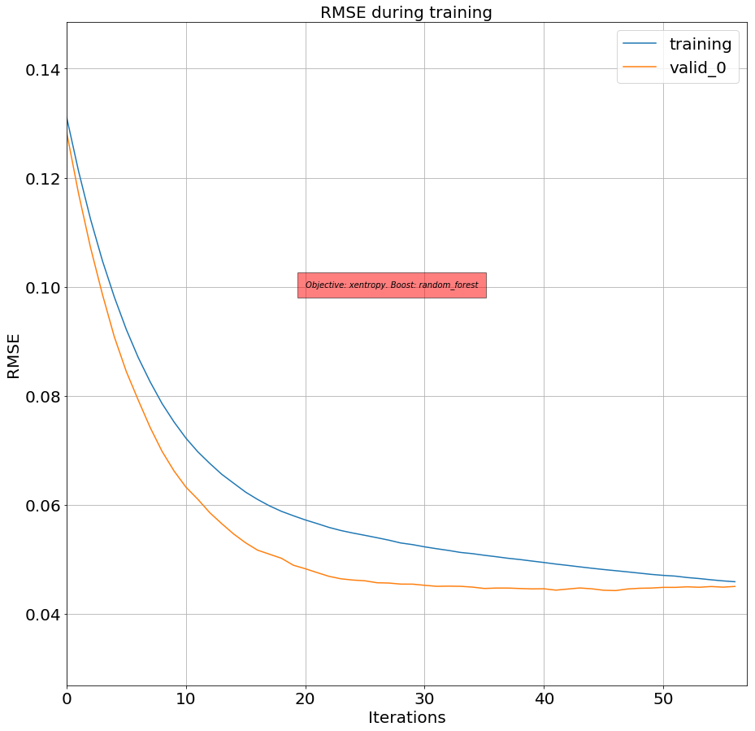

```python
obj = ["xentropy" ,"regression"]
boost = ["random_forest","gbdt",None]
met = ["xentropy","rmse"]
train,valid,test = split_data(data)
#all = obj + boost
for me in met:
    for ob in obj:
        for bo in boost:
            #eval_result = {}
            #global m
            training(train,valid,ob,me,bo,test)

plt.show()
#https://matplotlib.org/3.1.1/tutorials/text/text_intro.html
#https://python4astronomers.github.io/plotting/advanced.html
```

```python
#training(data)
results
#type(results[0])
```

```
['Model with objective as xentropy, metric as rmse, and boosting as random_forest. Score/error : 0.00196092',
 'Model with objective as xentropy, metric as rmse, and boosting as gbdt. Score/error : 0.00196092',
 'Model with objective as xentropy, metric as rmse, and boosting as None. Score/error : 0.00196092',
 'Model with objective as regression, metric as rmse, and boosting as random_forest. Score/error : 0.00208685',
 'Model with objective as regression, metric as rmse, and boosting as gbdt. Score/error : 0.00208685',
 'Model with objective as regression, metric as rmse, and boosting as None. Score/error : 0.00208685']
```

```python
def find_min(data):
    baseline_err = float(1)
    mod = ""
    if type(data) is list:
        for each in data:
        #print("each ", each, " type : ", type(each))
            v = re.findall("\d+\.\d+",each)
        #print("our v : ", v)
            if float(v[0]) < baseline_err:
                baseline_err = float(v[0])
                mod = each
    else:
        for each in data:
            v = re.findall("\d+\.\d+",str(data[each]))
        #print("our v : ", v)
            if float(v[0]) < baseline_err:
                baseline_err = float(v[0])
                mod = each + " : " + str(data[each])

    return mod
```

```python
best_mod = find_min(results)
print("our best model : ", best_mod)
baseline_err = re.findall("\d+\.\d+",best_mod)
print("base ", baseline_err[0])
### SAVE THE PARAMETERS INTO A DICTIONARY
par = {"objective":"","metric":"","boosting":""}
para = []
def get_par():
    idx = 0
    vir = 0
    while idx < len(best_mod) and idx != -1:
        idx = best_mod.find("as", idx+1)
        vir = best_mod.find(",", vir+1)
        if vir == -1:
            vir = best_mod.find(".")
        if idx == -1:
            break
        obj = best_mod[(idx+3):vir]
        para.append(obj)
        #print("our obj :", obj)
    i = 0
    for key in par:
        par[key] = para[i]
        i+=1
    print(par)
get_par()
```

```
our best model :  Model with objective as xentropy, metric as rmse, and boosting as random_forest. Score/error : 0.00196092
base  0.00196092
{'objective': 'xentropy', 'metric': 'rmse', 'boosting': 'random_forest'}
```

Now lets create new features and see how it interfers in the model performance

```python
import category_encoders as ce
all_res = {} # dictionary with anders models and ihr results
all_res["baseline"] = baseline_err[0]
#train,valid,test = split_data(data)
```

INTERACTION (CGPA-GRE and CGPA-TOEFL)

```python
from sklearn.preprocessing import LabelEncoder
inter = pd.DataFrame(index=data.index) #### DATA
var = pd.DataFrame(index=data.index)#### DATA
#train,valid,_ = split_data(data)

lb_enc = LabelEncoder()
inter_ft = ['GRE Score', 'TOEFL Score']
for each in inter_ft:
    name = "CGPA_"+each
    nameVar = each+"_admitVar"
    inter[name] = lb_enc.fit_transform(data["CGPA"].apply(str)+"_"+data[each].apply(str)) ### DATA
    data[name] = inter[name] #### DATA
    #valid[name] =
#     var[nameVar]= train[each].apply(fun)
#     train[nameVar] = var[nameVar]

train.head()
data.head()
```

| Serial No. | GRE Score | TOEFL Score | University Rating | SOP | LOR | CGPA | Research | Chance of Admit | CGPA_GRE Score | CGPA_TOEFL Score |
| --- | --- | --- | --- | --- | --- | --- | --- | --- | --- | --- |
| 1 | 337 | 118 | 4 | 4.5 | 4.5 | 9.65 | 1 | 0.92 | 447 | 425 |
| 2 | 324 | 107 | 4 | 4.0 | 4.5 | 8.87 | 1 | 0.76 | 311 | 293 |
| 3 | 316 | 104 | 3 | 3.0 | 3.5 | 8.00 | 1 | 0.72 | 106 | 97 |
| 4 | 322 | 110 | 3 | 3.5 | 2.5 | 8.67 | 1 | 0.80 | 264 | 248 |
| 5 | 314 | 103 | 2 | 2.0 | 3.0 | 8.21 | 0 | 0.65 | 140 | 128 |

Lets see how the model performes:

```
vsize =  50
Models erros : {'baseline': '0.00196092', 'interaction': 0.00185012}
Performance quality (>1 worse):  0.9434947273296419
parameters :  rmse
Plot feature importances...
```

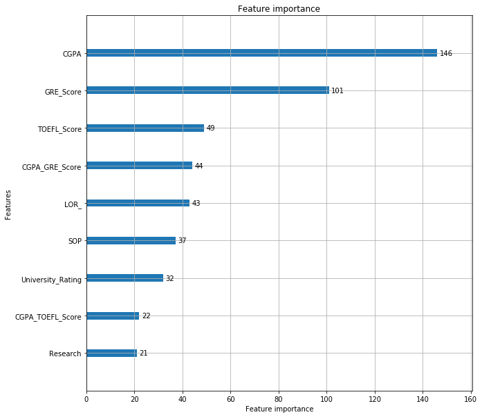

```
Plot tree:
```

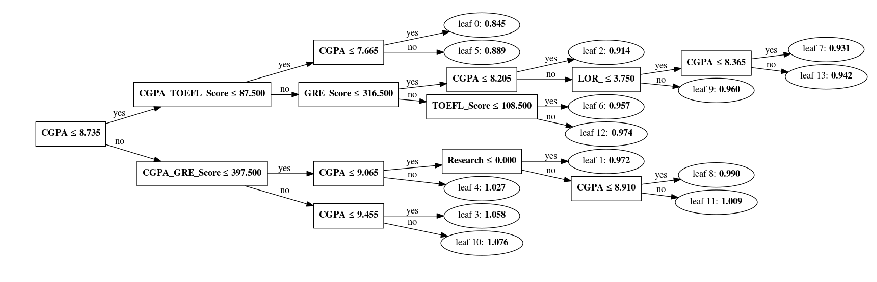

```python
train,valid,test = split_data(data)
res = training(train,valid,par["objective"],par["metric"],par["boosting"],test)
all_res["interaction"] = res[1].round(8)
#print(f"Our model performance error: {res[1]:.4f}")
print(f"Models erros : {all_res}")
print("Performance quality (>1 worse): ", float(res[1])/float(baseline_err[0]))
print("parameters : ", par["metric"])

print('Plot feature importances...')
ax = lbg.plot_importance(res[0], max_num_features=10,figsize=(10,10))
plt.show()
print("Plot tree: ")
ax = lbg.plot_tree(res[0],figsize=(15,15))
plt.show()
#res[0]
```

Count Encoding:

```python
feat = ['GRE Score', 'TOEFL Score','CGPA']
enc = pd.DataFrame(index=train.index)


c_enc = ce.CountEncoder(cols=feat)
c_enc.fit(data[feat]) #### TRAIN
try:
    #data = data.join(c_enc.transform(data[feat]).add_suffix("_count"))
    train = train.join(c_enc.transform(train[feat]).add_suffix("_count"))
    valid = valid.join(c_enc.transform(valid[feat]).add_suffix("_count"))
    train.head()
except:
    print("we have already create the columns!")
    print(train.head())
```

```python
train.tail()
```

| Serial No. | GRE Score | TOEFL Score | University Rating | SOP | LOR | CGPA | Research | Chance of Admit | CGPA_GRE Score | CGPA_TOEFL Score | GRE Score_count | TOEFL Score_count | CGPA_count |
| --- | --- | --- | --- | --- | --- | --- | --- | --- | --- | --- | --- | --- | --- |
| 396 | 324 | 110 | 3 | 3.5 | 3.5 | 9.04 | 1 | 0.82 | 346 | 326 | 23 | 44 | 6 |
| 397 | 325 | 107 | 3 | 3.0 | 3.5 | 9.11 | 1 | 0.84 | 364 | 342 | 15 | 28 | 6 |
| 398 | 330 | 116 | 4 | 5.0 | 4.5 | 9.45 | 1 | 0.91 | 430 | 408 | 8 | 16 | 4 |
| 399 | 312 | 103 | 3 | 3.5 | 4.0 | 8.78 | 0 | 0.67 | 295 | 280 | 24 | 25 | 5 |
| 400 | 333 | 117 | 4 | 5.0 | 4.0 | 9.66 | 1 | 0.95 | 448 | 427 | 4 | 8 | 3 |

```python
train.isnull().sum()
```

```
GRE Score            0
TOEFL Score          0
University Rating    0
SOP                  0
LOR                  0
CGPA                 0
Research             0
Chance of Admit      0
CGPA_GRE Score       0
CGPA_TOEFL Score     0
GRE Score_count      0
TOEFL Score_count    0
CGPA_count           0
dtype: int64
```

```python
valid.isnull().sum()
```

```
GRE Score            0
TOEFL Score          0
University Rating    0
SOP                  0
LOR                  0
CGPA                 0
Research             0
Chance of Admit      0
CGPA_GRE Score       0
CGPA_TOEFL Score     0
GRE Score_count      0
TOEFL Score_count    0
CGPA_count           0
dtype: int64
```

Handling Nan values:

```python
# data.fillna(data["CGPA_count"].mean(),inplace=True)
# data["CGPA_count"] = data["CGPA_count"].astype(int)
# data.tail(10)
# data.isnull().sum()
```

Lets see the model performance:

```python
#train,valid,test = split_data(data)
res = training(train,valid,par["objective"],par["metric"],par["boosting"])
print(f"Our model performance error: {res[1]:.6f}")

all_res["count"] = res[1].round(8)
#print(f"Our model performance error: {res[1]:.4f}")
print(f"Models erros : {all_res}")
print("Performance quality (>1 worse): ", float(res[1])/float(baseline_err[0]))
```

```
Our model performance error: 0.001828
Models erros : {'baseline': '0.00196092', 'interaction': 0.00185012, 'count': 0.00182814}
Performance quality (>1 worse):  0.9322876891176981
```

Lets see how much the Chance of Admit varies (max-min) for each value of TOEFL, GRE and CGPA: (Take a look at the "GRAPHS" part in the bottom of the notebook)

```python
def fun(dat,name):

    def repl(ser):
        return t_val[ser]

    #print("our dat : ", dat)
    t_u = sorted(dat[name].unique())

    t_val = pd.Series(index=t_u)
    for un in dat[name].unique():
        t_max = dat.loc[(dat[name]==un)]["Chance of Admit "].max()
        t_min = dat.loc[(dat[name]==un)]["Chance of Admit "].min()
        t_val[un] = t_max - t_min
    #print("our t_val: ", t_val)
    #print("our t_val[0] : ", t_val[290])
    datafr = pd.DataFrame(index=dat.index)

    datafr = dat[name].apply(repl)

    return datafr
```

```python
from sklearn.preprocessing import LabelEncoder

#train,valid,_ = split_data(data)

inter = pd.DataFrame(index=train.index)
var = pd.DataFrame(index=train.index)
# inter = pd.DataFrame(index=data.index)
# var = pd.DataFrame(index=data.index)

inter_ft = ['GRE Score', 'TOEFL Score', "CGPA"]
for each in inter_ft:
    #print("our each is : ", each)
    nameVar = each+"_admitVar"
    #nameVar = each+"_admitVarCount"

    #print("so our train[each] is ", train[each])
    var[nameVar]= fun(train,each)# train[each].apply(fun)
    train[nameVar] = var[nameVar]
    valid[nameVar] = var[nameVar]
    #data[nameVar] = var[nameVar]
    #train = train.join(var[nameVar].add_suffix(nameVar))

train.head()
```

| Serial No. | GRE Score | TOEFL Score | University Rating | SOP | LOR | CGPA | Research | Chance of Admit | CGPA_GRE Score | CGPA_TOEFL Score | GRE Score_count | TOEFL Score_count | CGPA_count | GRE Score_admitVar | TOEFL Score_admitVar | CGPA_admitVar |
| --- | --- | --- | --- | --- | --- | --- | --- | --- | --- | --- | --- | --- | --- | --- | --- | --- |
| 1 | 337 | 118 | 4 | 4.5 | 4.5 | 9.65 | 1 | 0.92 | 447 | 425 | 2 | 10 | 1 | 0.00 | 0.04 | 0.00 |
| 2 | 324 | 107 | 4 | 4.0 | 4.5 | 8.87 | 1 | 0.76 | 311 | 293 | 23 | 28 | 3 | 0.20 | 0.31 | 0.09 |
| 3 | 316 | 104 | 3 | 3.0 | 3.5 | 8.00 | 1 | 0.72 | 106 | 97 | 18 | 29 | 9 | 0.28 | 0.40 | 0.32 |
| 4 | 322 | 110 | 3 | 3.5 | 2.5 | 8.67 | 1 | 0.80 | 264 | 248 | 17 | 44 | 5 | 0.27 | 0.46 | 0.09 |
| 5 | 314 | 103 | 2 | 2.0 | 3.0 | 8.21 | 0 | 0.65 | 140 | 128 | 16 | 25 | 3 | 0.30 | 0.19 | 0.10 |

Performance:

```python
#train,valid,test = split_data(data)
res = training(train,valid,par["objective"],par["metric"],par["boosting"])
print(f"Our model performance error: {res[1]:.8f}")

all_res["admi_var"] = res[1].round(8)
#print(f"Our model performance error: {res[1]:.4f}")
print(f"Models erros : {all_res}")
print("Performance quality (>1 worse): ", float(res[1])/float(baseline_err[0]))
```

```
Our model performance error: 0.00203064
Models erros : {'baseline': '0.00196092', 'interaction': 0.00185012, 'count': 0.00182814, 'admi_var': 0.00203064}
Performance quality (>1 worse):  1.0355528503015452
```

Now lets create another feature that is the count of the Admit Variance:

```python
col = train.columns[-3:]
print("col : ", col)
feat = col
enc2 = pd.DataFrame(index=train.index)


c_enc = ce.CountEncoder(cols=feat)
c_enc.fit(train[feat]) ##################################" !!!!!"
try:
    #data = data.join(c_enc.transform(data[feat]).add_suffix("_countVar"))
    train = train.join(c_enc.transform(train[feat]).add_suffix("_countVar"))
    valid = valid.join(c_enc.transform(valid[feat]).add_suffix("_countVar"))
    train.head()
except:
    print("we have already create the columns!")
    print(train.head())

data.head()
train.head()
# print("data columns ", data.columns)

# new_fet = data.drop(col, axis=1).columns
# new_fet
```

```
col :  Index(['GRE Score_admitVar', 'TOEFL Score_admitVar', 'CGPA_admitVar'], dtype='object')
```

| Serial No. | GRE Score | TOEFL Score | University Rating | SOP | LOR | CGPA | Research | Chance of Admit | CGPA_GRE Score | CGPA_TOEFL Score | GRE Score_count | TOEFL Score_count | CGPA_count | GRE Score_admitVar | TOEFL Score_admitVar | CGPA_admitVar | GRE Score_admitVar_countVar | TOEFL Score_admitVar_countVar | CGPA_admitVar_countVar |
| --- | --- | --- | --- | --- | --- | --- | --- | --- | --- | --- | --- | --- | --- | --- | --- | --- | --- | --- | --- |
| 1 | 337 | 118 | 4 | 4.5 | 4.5 | 9.65 | 1 | 0.92 | 447 | 425 | 2 | 10 | 1 | 0.00 | 0.04 | 0.00 | 2 | 9 | 73 |
| 2 | 324 | 107 | 4 | 4.0 | 4.5 | 8.87 | 1 | 0.76 | 311 | 293 | 23 | 28 | 3 | 0.20 | 0.31 | 0.09 | 19 | 26 | 27 |
| 3 | 316 | 104 | 3 | 3.0 | 3.5 | 8.00 | 1 | 0.72 | 106 | 97 | 18 | 29 | 9 | 0.28 | 0.40 | 0.32 | 44 | 25 | 9 |
| 4 | 322 | 110 | 3 | 3.5 | 2.5 | 8.67 | 1 | 0.80 | 264 | 248 | 17 | 44 | 5 | 0.27 | 0.46 | 0.09 | 26 | 37 | 7 |
| 5 | 314 | 103 | 2 | 2.0 | 3.0 | 8.21 | 0 | 0.65 | 140 | 128 | 16 | 25 | 3 | 0.30 | 0.19 | 0.10 | 14 | 16 | 14 |

Performance:

[output not shown]

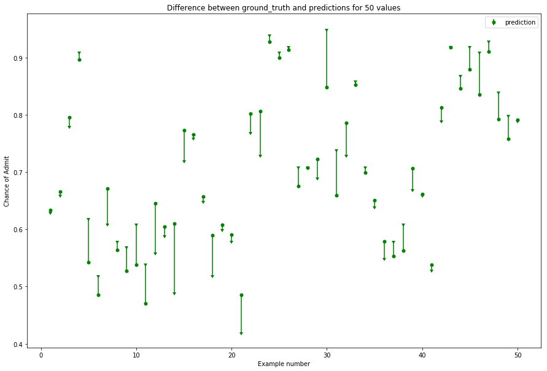

| Serial No. | Prediction | Ground_Truth | Error |
| --- | --- | --- | --- |
| 401 | 0.633896 | 0.63 | 0.003896 |
| 402 | 0.665286 | 0.66 | 0.005286 |
| 403 | 0.795355 | 0.78 | 0.015355 |
| 404 | 0.895844 | 0.91 | -0.014156 |
| 405 | 0.542661 | 0.62 | -0.077339 |

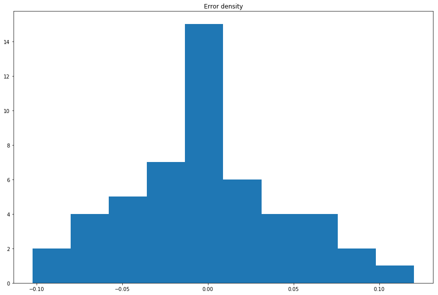

```python
#train,valid,test = split_data(data)
res = training(train,valid,par["objective"],par["metric"],par["boosting"])
print(f"Our model performance error: {res[1]:.8f}")

all_res["CountAdmi_var"] = res[1].round(8)
#print(f"Our model performance error: {res[1]:.4f}")
print(f"Models erros : {all_res}")
print("Performance quality (>1 worse): ", float(res[1])/float(baseline_err[0]))


#print("val pred : ", val_pred)
#print(" ground : ", ground.shape)
# p_test = bst.predict(x_test)
plt.figure(figsize=(15,10))
x = np.linspace(1,50,50)
# ground = ground.to_numpy()
# ground = [float(a) for a in ground]
val_pred = [float(b) for b in val_pred]
yerr = (((val_pred) - (ground))).to_numpy()
yerr = [float(a) for a in yerr]
#print(yerr[0], val_pred[0], ground.to_numpy()[0])
#print(yerr)


#print(type(yerr[0]),type(val_pred[0]), type(ground))
plt.errorbar(x,val_pred,yerr=yerr,marker = 'o',fmt='go',markersize=5,uplims=True,lolims = False, capsize=0,capthick=0,label="prediction")
plt.title("Difference between ground_truth and predictions for 50 values")
plt.ylabel("Chance of Admit")
plt.xlabel("Example number")
plt.legend()
plt.show()

diferr = pd.DataFrame(columns=["Prediction", "Ground_Truth", "Error"])
diferr["Ground_Truth"] = ground
diferr["Prediction"] = val_pred
diferr["Error"] = yerr

plt.figure(figsize=(15,10))
plt.hist(yerr)
plt.title("Error density")
diferr.head()
```

```python
#train.head()
```

Dropping the admi_Var cols:

```python
train = train.drop(col, axis=1)
valid = valid.drop(col, axis=1)
#data.head()

#train,valid,test = split_data(data)
res = training(train,valid,par["objective"],par["metric"],par["boosting"])
print(f"Our model performance error: {res[1]:.8f}")

all_res["Count_none_Admi_var"] = res[1].round(8)
#print(f"Our model performance error: {res[1]:.4f}")
print(f"Models erros : {all_res}")
print("Performance quality (>1 worse): ", float(res[1])/float(baseline_err[0]))
```

```
Our model performance error: 0.00167912
Models erros : {'baseline': '0.00196092', 'interaction': 0.00185012, 'count': 0.00182814, 'admi_var': 0.00203064, 'CountAdmi_var': 0.00163783, 'Count_none_Admi_var': 0.00167912}
Performance quality (>1 worse):  0.8562902029278002
```

Getting the best model:

```python
best_mod = find_min(all_res)
print("best_mod : ", best_mod)
```

```
best_mod :  CountAdmi_var : 0.00163783
```

Lets see now how Feature Selection would works here. Zwel anders methods will be implemented: Mutual Information and F-test

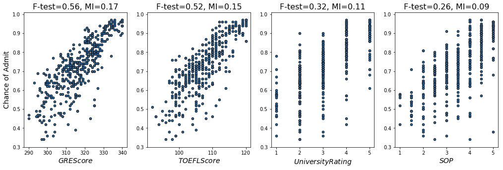

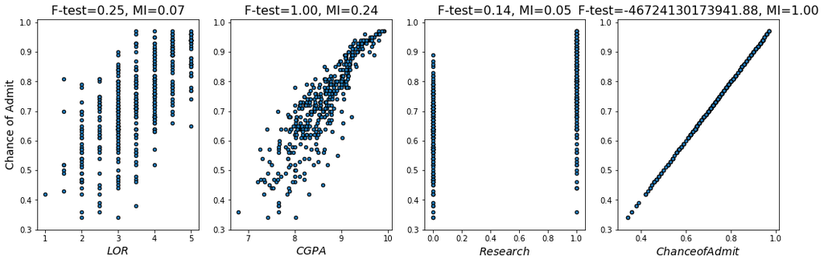

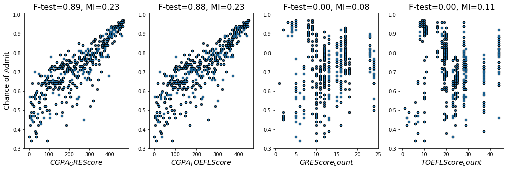

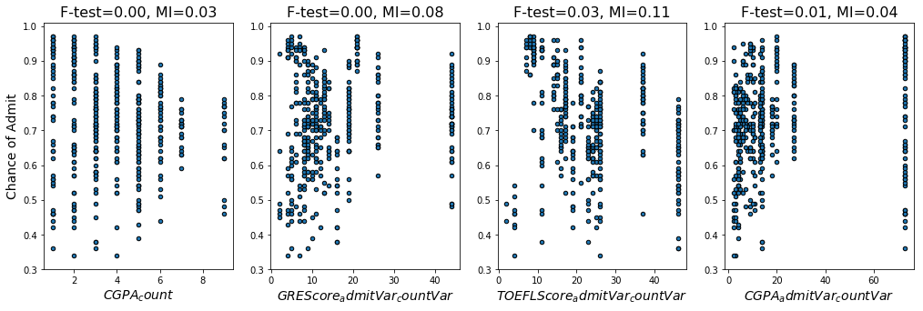

```python
from sklearn.feature_selection import f_regression, mutual_info_regression

f_test, _ = f_regression(train, train["Chance of Admit "])
f_test /= np.max(f_test)

mi = mutual_info_regression(train, train["Chance of Admit "])
mi /= np.max(mi)

plt.figure(figsize=(35, 5))
for i in range(int(len(train.columns)/4)):
    if i < 8:
        #plt.figure(figsize=(25, 15))
        plt.subplot(1, len(train.columns)/2, i + 1)
        plt.scatter(train.iloc[:, i], train["Chance of Admit "], edgecolor='black', s=20)
        plt.xlabel("${}$".format(train.columns[i]), fontsize=14)
        if i == 0:
            plt.ylabel("Chance of Admit", fontsize=14)
        plt.title("F-test={:.2f}, MI={:.2f}".format(f_test[i], mi[i]),
              fontsize=16)
plt.show()
plt.figure(figsize=(35, 5))
for i in range(4):
    #print("value of i :", i)
    plt.subplot(1, len(train.columns)/2, i + 1)
    plt.scatter(train.iloc[:, i+4], train["Chance of Admit "], edgecolor='black', s=20)
    plt.xlabel("${}$".format(train.columns[i+4]), fontsize=14)
    if i == 0:
        plt.ylabel("Chance of Admit", fontsize=14)
    plt.title("F-test={:.2f}, MI={:.2f}".format(f_test[i+4], mi[i+4]),fontsize=16)
plt.show()
plt.figure(figsize=(35, 5))
for i in range(4):
    #print("value of i :", i)
    plt.subplot(1, len(train.columns)/2, i + 1)
    plt.scatter(train.iloc[:, i+8], train["Chance of Admit "], edgecolor='black', s=20)
    plt.xlabel("${}$".format(train.columns[i+8]), fontsize=14)
    if i == 0:
        plt.ylabel("Chance of Admit", fontsize=14)
    plt.title("F-test={:.2f}, MI={:.2f}".format(f_test[i+8], mi[i+8]),fontsize=16)
plt.show()
plt.figure(figsize=(35, 5))
for i in range(4):
    #print("value of i :", i)
    plt.subplot(1, len(train.columns)/2, i + 1)
    plt.scatter(train.iloc[:, i+12], train["Chance of Admit "], edgecolor='black', s=20)
    plt.xlabel("${}$".format(train.columns[i+12]), fontsize=14)
    if i == 0:
        plt.ylabel("Chance of Admit", fontsize=14)
    plt.title("F-test={:.2f}, MI={:.2f}".format(f_test[i+12], mi[i+12]),fontsize=16)
plt.show()
```

```python
print("ftest : ", f_test)
print("mitest : ", mi)
```

```
ftest :  [ 5.63490130e-01  5.22345475e-01  3.18648904e-01  2.61542750e-01
  2.53372986e-01  1.00000000e+00  1.37256000e-01 -4.67241302e+13
  8.86996265e-01  8.79615568e-01  2.12392479e-07  2.34385101e-03
  4.05413244e-03  3.73592798e-03  3.29679844e-02  9.35055489e-03]
mitest :  [0.16769793 0.14964125 0.10650249 0.09199078 0.07488066 0.24357054
 0.04792891 1.         0.22808608 0.23364228 0.084468   0.10855223
 0.02501373 0.07759493 0.10546533 0.0425526 ]
```

```python
sel = {train.columns[key]:value for key,value in enumerate(f_test) if value > 0.50}

sel2 = {train.columns[key]:value for key,value in enumerate(mi) if value > 0.23}

print("sel1", sel)
print("sel2", sel2)
selected_feat = sel
```

```
sel1 {'GRE Score': 0.5634901296085584, 'TOEFL Score': 0.5223454752591521, 'CGPA': 1.0, 'CGPA_GRE Score': 0.8869962653471715, 'CGPA_TOEFL Score': 0.8796155681964782}
sel2 {'CGPA': 0.2435705372501241, 'Chance of Admit ': 1.0, 'CGPA_TOEFL Score': 0.23364227691154216}
```

```python
train.head()
```

| Serial No. | GRE Score | TOEFL Score | University Rating | SOP | LOR | CGPA | Research | Chance of Admit | CGPA_GRE Score | CGPA_TOEFL Score | GRE Score_count | TOEFL Score_count | CGPA_count | GRE Score_admitVar_countVar | TOEFL Score_admitVar_countVar | CGPA_admitVar_countVar |
| --- | --- | --- | --- | --- | --- | --- | --- | --- | --- | --- | --- | --- | --- | --- | --- | --- |
| 1 | 337 | 118 | 4 | 4.5 | 4.5 | 9.65 | 1 | 0.92 | 447 | 425 | 2 | 10 | 1 | 2 | 9 | 73 |
| 2 | 324 | 107 | 4 | 4.0 | 4.5 | 8.87 | 1 | 0.76 | 311 | 293 | 23 | 28 | 3 | 19 | 26 | 27 |
| 3 | 316 | 104 | 3 | 3.0 | 3.5 | 8.00 | 1 | 0.72 | 106 | 97 | 18 | 29 | 9 | 44 | 25 | 9 |
| 4 | 322 | 110 | 3 | 3.5 | 2.5 | 8.67 | 1 | 0.80 | 264 | 248 | 17 | 44 | 5 | 26 | 37 | 7 |
| 5 | 314 | 103 | 2 | 2.0 | 3.0 | 8.21 | 0 | 0.65 | 140 | 128 | 16 | 25 | 3 | 14 | 16 | 14 |

```python
train = train.drop([train.columns[i] for i in range(len(train.columns)) if train.columns[i] not in selected_feat.keys() and train.columns[i] != "Chance of Admit "], axis=1)
valid = valid.drop([valid.columns[i] for i in range(len(valid.columns)) if valid.columns[i] not in selected_feat.keys() and valid.columns[i] != "Chance of Admit "], axis=1)

#data.head()

#train,valid,test = split_data(data)
res = training(train,valid,par["objective"],par["metric"],par["boosting"])
print(f"Our model performance error: {res[1]:.8f}")

all_res["FEAT_SEL"] = res[1].round(8)
#print(f"Our model performance error: {res[1]:.4f}")
print(f"Models erros : {all_res}")
print("Performance quality (>1 worse): ", float(res[1])/float(baseline_err[0]))
```

```
Our model performance error: 0.00197250
Models erros : {'baseline': '0.00196092', 'interaction': 0.00185012, 'count': 0.00182814, 'admi_var': 0.00203064, 'CountAdmi_var': 0.00163783, 'Count_none_Admi_var': 0.00167912, 'FEAT_SEL': 0.0019725}
Performance quality (>1 worse):  1.005905890748508
```

```python
all_res
```

```
{'baseline': '0.00196092',
 'interaction': 0.00185012,
 'count': 0.00182814,
 'admi_var': 0.00203064,
 'CountAdmi_var': 0.00163783,
 'Count_none_Admi_var': 0.00167912,
 'FEAT_SEL': 0.0019725}
```

```
['baseline', 'interaction', 'count', 'admi_var', 'CountAdmi_var', 'Count_none_Admi_var', 'FEAT_SEL']
[0.00196092, 0.00185012, 0.00182814, 0.00203064, 0.00163783, 0.00167912, 0.0019725]
```

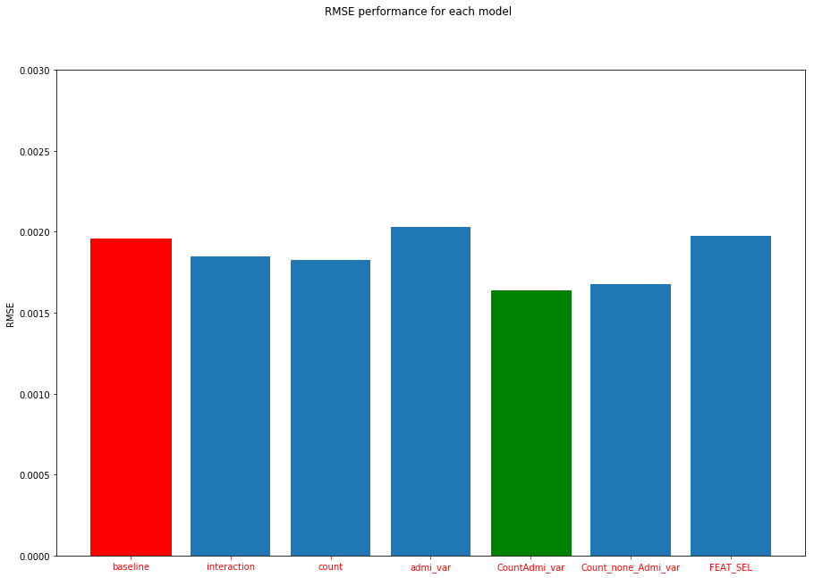

```python
plt.figure()
X = []
error = []

for t, er in all_res.items():
    X.append(t)
    error.append(float(er))
print(X)
print(error)
plt.figure(figsize=(15, 10))

#plt.subplot(131)
plt.ylabel("RMSE")
e = plt.bar(X, error)#color=['black', 'red', 'green', 'blue', 'cyan','orange','gray'])
e[0].set_color('r')
e[4].set_color("g")
plt.xticks()
plt.ylim(0.0,0.003)
plt.tick_params(axis='x', colors='red')

plt.suptitle('RMSE performance for each model')
plt.show()
```

What is interesting to notice is that even if the performance is 0.5% worse than our baseline model, we did so with 2 features less than the original data. That is, we can almost predict the same with less 2 columns less data.

```python
# fig,ax = plt.subplots(1,3,figsize=(10,10))
# var = ["TOEFL Score_admitVar", "GRE Score_admitVar", "CGPA_admitVar"]
# for i in range(3):
#     sns.scatterplot(x=train[var[i]],y=train["Chance of Admit "], ax=ax[i])
```

```
                                                                    **GRAPHS!!**
```

The following charts show us that the highest chance of admission is where the TOEFL, GRE and CGPA varie less, although the number of samples is also smaller (with execption to CGPA): (you'll have to run all the cells before to run them properly!). Some of these graphs show redundant information but with slightly different changes in the visualization mode.

```python
data = pd.read_csv("../input/graduate-admissions/Admission_Predict_Ver1.1.csv", index_col = "Serial No." )

data.head()

from sklearn.preprocessing import LabelEncoder

#train,valid,_ = split_data(data)

inter = pd.DataFrame(index=train.index)
var = pd.DataFrame(index=train.index)
# inter = pd.DataFrame(index=data.index)
# var = pd.DataFrame(index=data.index)

inter_ft = ['GRE Score', 'TOEFL Score', "CGPA"]
for each in inter_ft:
    #print("our each is : ", each)
    nameVar = each+"_admitVar"
    #nameVar = each+"_admitVarCount"
    #print("so our train[each] is ", train[each])
    var[nameVar]= fun(train,each)# train[each].apply(fun)
    train[nameVar] = var[nameVar]
    valid[nameVar] = var[nameVar]
    #data[nameVar] = var[nameVar]
    #train = train.join(var[nameVar].add_suffix(nameVar))

train.head()
```

| Serial No. | GRE Score | TOEFL Score | CGPA | Chance of Admit | CGPA_GRE Score | CGPA_TOEFL Score | GRE Score_admitVar | TOEFL Score_admitVar | CGPA_admitVar |
| --- | --- | --- | --- | --- | --- | --- | --- | --- | --- |
| 1 | 337 | 118 | 9.65 | 0.92 | 447 | 425 | 0.00 | 0.04 | 0.00 |
| 2 | 324 | 107 | 8.87 | 0.76 | 311 | 293 | 0.20 | 0.31 | 0.09 |
| 3 | 316 | 104 | 8.00 | 0.72 | 106 | 97 | 0.28 | 0.40 | 0.32 |
| 4 | 322 | 110 | 8.67 | 0.80 | 264 | 248 | 0.27 | 0.46 | 0.09 |
| 5 | 314 | 103 | 8.21 | 0.65 | 140 | 128 | 0.30 | 0.19 | 0.10 |

What we want to assess is how much a certain value of score (TOEFL, GRE or CGPA) is indicative of a more precise prediction of our output (Chance of Admit). Is 115 in TOEFL a greater indication to determine the candidate's Chance of Admit independetly of other variables?

From the graph below, we could eventually identify 4 clusters of TOEFL Scores:

```python
import plotly.graph_objects as go
import plotly.express as px
import pandas as pd

xs = {"lab":"TOEFL Score_admitVar", 1:train["TOEFL Score_admitVar"]}
zs = {"lab":"TOEFL Score",1:train["TOEFL Score"]}
ys = {"lab":"Chance of Admit",1:train["Chance of Admit "]}

fig = px.scatter_3d(train, x=xs[1], y=ys[1], z=zs[1],
              color=zs[1])
fig.show()

#https://plot.ly/python/3d-scatter-plots/
```

[interactive chart not shown]

[interactive chart not shown]

[figure not shown]

```python
fig,ax = plt.subplots(1,3,figsize=(10,10))
var = ["TOEFL Score_admitVar", "GRE Score_admitVar", "CGPA_admitVar"]
var2 = ["TOEFL Score", "GRE Score", "CGPA"]
for i in range(3):
    #sns.scatterplot(x=train[var[i]],y=train["Chance of Admit "], ax=ax[i])

#     xs = {"lab":"TOEFL Score_admitVar", 1:train["TOEFL Score_admitVar"]}
#     zs = {"lab":"TOEFL Score",1:train["TOEFL Score"]}
#     ys = {"lab":"Chance of Admit",1:train["Chance of Admit "]}

    xs = {"lab":var[i],1:train[var[i]]}
    zs = {"lab":var2[i],1:train[var2[i]]}
    ys = {"lab":"Chance of Admit",1:train["Chance of Admit "]}

    #ys = {"lab":var[i],1:train[var[i]]}
    fig = px.scatter_3d(train, x=xs[1], y=ys[1], z=zs[1],
              color=zs[1])

    fig.show()
```

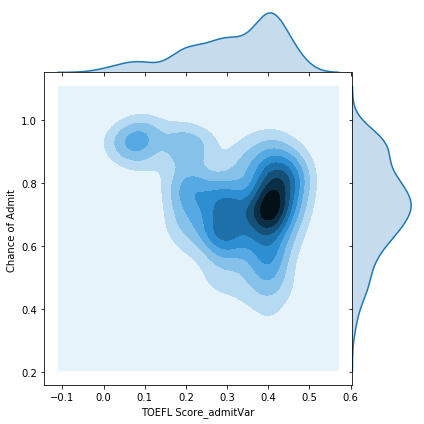

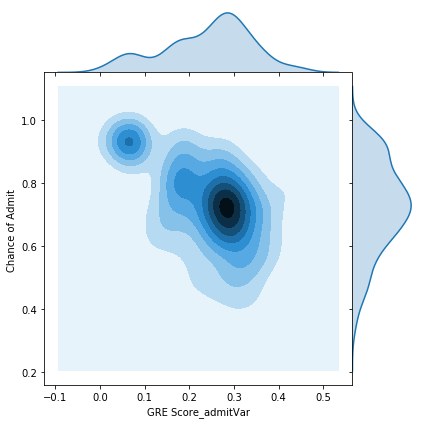

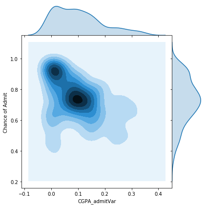

```python
#fig2,ax2 = plt.subplots(1,3,figsize=(15,15))
var = ["TOEFL Score_admitVar", "GRE Score_admitVar", "CGPA_admitVar"]
for i in range(3):
    sns.jointplot(train[var[i]],train["Chance of Admit "],data=train, space=0, kind="kde")
    #sns.scatterplot(train["TOEFL Score"],train["Chance of Admit "])
```

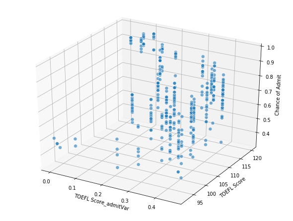

```python
import matplotlib.pyplot as plt
from mpl_toolkits.mplot3d import axes3d, Axes3D #<-- Note the capitalization!
#fig = plt.figure()



fig = plt.figure(figsize=(8, 6))
#ax = fig.add_subplot(111, projection='3d')
ax = Axes3D(fig)
xs = {"lab":"TOEFL Score_admitVar", 1:train["TOEFL Score_admitVar"]}
ys = {"lab":"TOEFL Score",1:train["TOEFL Score"]}
zs = {"lab":"Chance of Admit",1:train["Chance of Admit "]}
#xs =[[train["TOEFL Score_admitVar"]],["TOEFL Score_admitVar"]]
# ys = [[train["TOEFL Score"]],["TOEFL Score"]]
# zs = [[train["Chance of Admit "]],["Chance of Admit"]]
#print(xs[1])
ax.scatter(xs[1], ys[1], zs[1], s=50, alpha=0.6, edgecolors='w')

ax.set_xlabel(xs["lab"])
ax.set_ylabel(ys["lab"])
ax.set_zlabel(zs["lab"])

plt.show()

# https://plot.ly/python/3d-surface-plots/
# https://jovianlin.io/data-visualization-seaborn-part-3/
```

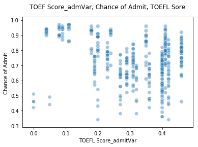

```python
plt.scatter(x = train["TOEFL Score_admitVar"],
            y = train['Chance of Admit '],
            s = train['TOEFL Score']*0.525, # <== 😀 Look here!
            alpha=0.4,
            edgecolors='w')

plt.xlabel('TOEFL Score_admitVar')
plt.ylabel('Chance of Admit ')
plt.title('TOEF Score_admVar, Chance of Admit, TOEFL Sore', y=1.05)
```

We could cluster candidates by groups of TOEFL, GRE & CGPA Scores. From the previous graphs, we could roughly separate in 4 groups. We can then, eventually, create a categorical feature (group pertainance) and create another graph with this feature as "color" parameter.

```python
#fig,ax = plt.subplots(1,3,figsize=(10,10))
var = ["TOEFL Score_admitVar", "GRE Score_admitVar", "CGPA_admitVar"]
var2 = ["TOEFL Score", "GRE Score", "CGPA"]
i=1
xs = {"lab":var2[0],1:train[var2[0]]}
zs = {"lab":var2[1],1:train[var2[1]]}
ys = {"lab":"Chance of Admit",1:train[var2[2]]}

    #ys = {"lab":var[i],1:train[var[i]]}
fig = px.scatter_3d(train, x=xs[1], y=ys[1], z=zs[1],
              color=train["Chance of Admit "])

fig.show()
```

[interactive chart not shown]

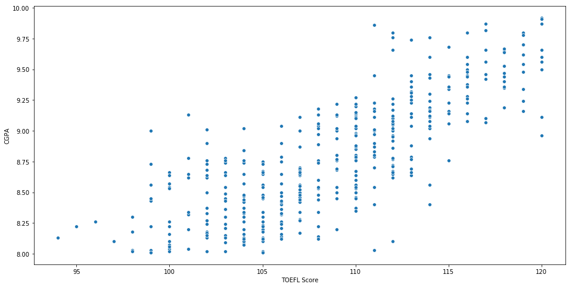

```python
plt.figure(figsize=(16,8))
val = data.loc[(data["CGPA"] > 8) & (data["CGPA"] < 10)]
#print(val)
sns.scatterplot(y= val["CGPA"], x=val["TOEFL Score"])
# sns.scatterplot(x= data["CGPA"], y=data.loc["Chance of Admit "],ax=ax[1])
# sns.distplot(data["TOEFL Score"],bins=20, kde=False,ax=ax[2])
```